# Bnlearn for Python

Welcome to the notebook of **bnlearn**. bnlearn is Python package for learning the graphical structure of Bayesian networks, parameter learning, inference and sampling methods. Because probabilistic graphical models can be difficult in usage, Bnlearn for python (this package) is build on the pgmpy package and contains the most-wanted pipelines. Navigate to API documentations for more detailed information.

The core functionalities are:  
* Causal Discovery  
* Structure Learning  
* Parameter Learning  
* Inferences using do-calculus

### Read the Medium blogs.

[1. A Step-by-Step Guide in detecting causal relationships using Bayesian Structure Learning in Python](https://towardsdatascience.com/a-step-by-step-guide-in-detecting-causal-relationships-using-bayesian-structure-learning-in-python-c20c6b31cee5)

[2. A step-by-step guide in designing knowledge-driven models using Bayesian theorem.](https://towardsdatascience.com/a-step-by-step-guide-in-designing-knowledge-driven-models-using-bayesian-theorem-7433f6fd64be)

[3. The Power of Bayesian Causal Inference: A Comparative Analysis of Libraries to Reveal Hidden Causality in Your Dataset.](https://towardsdatascience.com/the-power-of-bayesian-causal-inference-a-comparative-analysis-of-libraries-to-reveal-hidden-d91e8306e25e)

[4. Chat with Your Dataset using Bayesian Inferences.](https://towardsdatascience.com/chat-with-your-dataset-using-bayesian-inferences-bfd4dc7f8dcd)

### Support

This library is for free but it runs on coffee! :)

You can [support](https://erdogant.github.io/pca/pages/html/Documentation.html) in various ways, have a look at the [sponser page](https://erdogant.github.io/bnlearn/pages/html/Documentation.html). Report bugs, issues and feature extensions at [github page](https://github.com/erdogant/bnlearn).

```python
# Install packages
!pip install bnlearn
!pip install datazets
```

[output not shown]

```python
# Import libraries
import bnlearn as bn
import datazets as dz
import numpy as np
```

```python
# Get the data science salary data set
df = dz.get('ds_salaries')
```

```
[datazets] >INFO> Import dataset [ds_salaries]
[datazets] >INFO> Downloading [ds_salaries.zip] dataset from github source..
```

## Pre-processing steps

#### **Complexity is a major limitation**

When features contain many categories, the number of probability distributions required to populate a conditional probability table (CPT) in a Bayesian network, grows exponentially with the number of parent nodes associated with that table. Or in other words, when you increase the number of categories, it requires a lot more data to gain reliable results. Intuitively it is as follows; when you hierarchically split the data into categories, the number of samples within a single category will become smaller after each split. The low number of samples per category directly affects the statistical power. In our example, we have a feature job_title that contains 99 unique titles for which only 14 job titles contain more than 25 samples. To make sure this feature is not removed and can be used in a reliable manner, we need to aggregate some of the job titles. In the code section below we will aggregate job titles into 7 main categories. This results in a good proportion of samples per category for modeling.

```python
# Create new feature: Country
df['country'] = 'USA'
countries_europe = ['SM', 'DE', 'GB', 'ES', 'FR', 'RU', 'IT', 'NL', 'CH', 'CF', 'FI', 'UA', 'IE', 'GR', 'MK', 'RO', 'AL', 'LT', 'BA', 'LV', 'EE', 'AM', 'HR', 'SI', 'PT', 'HU', 'AT', 'SK', 'CZ', 'DK', 'BE', 'MD', 'MT']
df['country'][np.isin(df['company_location'], countries_europe)]='europe'
```

```python
# Rename catagorical variables for better understanding
df['experience_level'] = df['experience_level'].replace({'EN': 'Entry-level', 'MI': 'Junior Mid-level', 'SE': 'Intermediate Senior-level', 'EX': 'Expert Executive-level / Director'}, regex=True)
df['employment_type'] = df['employment_type'].replace({'PT': 'Part-time', 'FT': 'Full-time', 'CT': 'Contract', 'FL': 'Freelance'}, regex=True)
df['company_size'] = df['company_size'].replace({'S': 'Small (less than 50)', 'M': 'Medium (50 to 250)', 'L': 'Large (>250)'}, regex=True)
df['remote_ratio'] = df['remote_ratio'].replace({0: 'No remote', 50: 'Partially remote', 100: '>80% remote'}, regex=True)
```

```python
# Group similar job titles
titles = [['data scientist', 'data science', 'research', 'applied', 'specialist', 'ai', 'machine learning'],
          ['engineer', 'etl'],
          ['analyst', 'bi', 'business', 'product', 'modeler', 'analytics'],
          ['manager', 'head', 'director'],
          ['architect', 'cloud', 'aws'],
          ['lead/principal', 'lead', 'principal'],
          ]

job_title = df['job_title'].str.lower().copy()
df['job_title'] = 'Other'
for t in titles:
    for name in t:
        df['job_title'][list(map(lambda x: name in x, job_title))]=t[0]

# engineer          1654
# data scientist    1238
# analyst            902
# manager            158
# architect          118
# lead/principal      55
# Other                9
# Name: job_title, dtype: int64
```

# Discretize the continous variable salary

We also need to discretize salary_in_usd which can be done manually or using the discretizer function in bnlearn. For demonstration purposes, let's do both. For the latter case, we assume that salary depends on experience_level and on the country. Based on these input variables, the salary is then partitioned into bins (see code section below).

```python
discretize_method='manual'

if discretize_method=='manual':
    salary_in_usd = df['salary_in_usd']
    # Remove redundant variables
    df.drop(labels=['salary_currency', 'salary', 'salary_in_usd'], inplace=True, axis=1)
    # Set salary
    df['salary_in_usd'] = None
    df['salary_in_usd'].loc[salary_in_usd<60000]='<60K'
    df['salary_in_usd'].loc[np.logical_and(salary_in_usd>=60000, salary_in_usd<100000)]='60-100K'
    df['salary_in_usd'].loc[np.logical_and(salary_in_usd>=100000, salary_in_usd<160000)]='100-160K'
    df['salary_in_usd'].loc[np.logical_and(salary_in_usd>=160000, salary_in_usd<250000)]='160-250K'
    df['salary_in_usd'].loc[salary_in_usd>=250000]='>250K'
else:
    # Discritize salary
    tmpdf = df[['experience_level', 'salary_in_usd', 'country']]
    # Create edges
    edges = [('experience_level', 'salary_in_usd'), ('country', 'salary_in_usd')]
    # Create DAG based on edges
    DAG = bn.make_DAG(edges)
    bn.plot(DAG)
    # Discretize the continous columns
    df_disc = bn.discretize(tmpdf, edges, ["salary_in_usd"], max_iterations=1)
    df['salary_in_usd'] = df_disc['salary_in_usd']
    df['salary_in_usd'].value_counts()
    # Remove redundant variables
    df.drop(labels=['salary_currency', 'salary'], inplace=True, axis=1)
```

# Learn the causal DAG from the data.

At this point, we have pre-processed the data set and are ready to learn the causal structure. There are six algorithms implemented in bnlearn that can help for this task:

```
'hc' or 'hillclimbsearch' (default)
'ex' or 'exhaustivesearch'
'cs' or 'constraintsearch'
'cl' or 'chow-liu' (requires setting root_node parameter)
'nb' or 'naivebayes' (requires <root_node>)
'tan' (requires <root_node> and <class_node> parameter)
```

```python
# %% Learn the causal DAG from the data

# Structure learning
model = bn.structure_learning.fit(df, methodtype='hc', scoretype='bic')
```

```
[bnlearn] >Computing best DAG using [hc]
[bnlearn] >Set scoring type at [bic]
[bnlearn] >Compute structure scores for model comparison (higher is better).
```

```python
# independence test
model = bn.independence_test(model, df, prune=False)
```

```
[bnlearn] >Compute edge strength with [chi_square]
```

```python
# Check best scoring type
best_scoretype = min(model['structure_scores'], key=lambda k: model['structure_scores'][k])
print(best_scoretype)
```

```
bic
```

```python
# Parameter learning
model = bn.parameter_learning.fit(model, df, methodtype="bayes")
```

[output not shown]

[output cut: 363 more lines]

```
| job_title(Other)          | ... | 0.06770480704129994  |
+---------------------------+-----+----------------------+
| job_title(analyst)        | ... | 0.0961408259986459   |
+---------------------------+-----+----------------------+
| job_title(architect)      | ... | 0.0914014895057549   |
+---------------------------+-----+----------------------+
| job_title(data scientist) | ... | 0.21699390656736628  |
+---------------------------+-----+----------------------+
| job_title(engineer)       | ... | 0.3425863236289777   |
+---------------------------+-----+----------------------+
| job_title(lead/principal) | ... | 0.07718348002708192  |
+---------------------------+-----+----------------------+
| job_title(manager)        | ... | 0.10798916723087339  |
+---------------------------+-----+----------------------+
[bnlearn] >Compute structure scores for model comparison (higher is better).
```

```
[bnlearn] >Set node properties.
[bnlearn]> Set edge weights based on the [chi_square] test statistic.
[bnlearn] >Set edge properties.
[bnlearn] >Plot based on Bayesian model
```

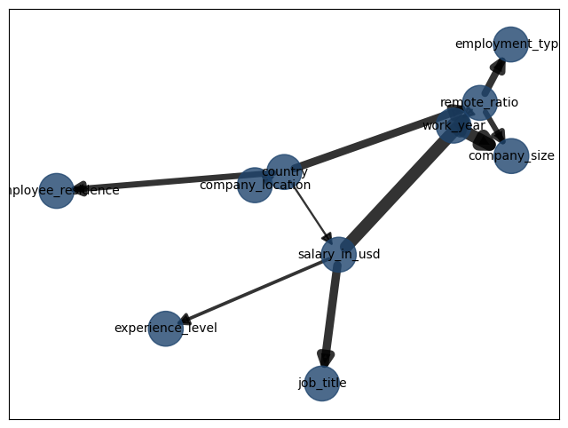

```python
# Plot
# bn.plot(model, params_static={'layout': 'planar_layout'}, title='method=hc and score=bic')
bn.plot(model, title='method=hc and score=bic', params_static={'figsize': (8, 6), 'arrowsize': 20, 'font_size': 10});
```

```python
!pip install d3blocks
# bn.plot(model, interactive=True, params_interactive={'notebook': True});
```

# Make inferences using do-calculus

```python
query = bn.inference.fit(model, variables=['job_title'],
                         evidence={'company_size': 'Large (>250)'})
```

```
[bnlearn] >Variable Elimination..
[bnlearn] >Data is stored in [query.df]
+----+----------------+-----------+
|    | job_title      |         p |
+====+================+===========+
|  0 | Other          | 0.0314356 |
+----+----------------+-----------+
|  1 | analyst        | 0.207313  |
+----+----------------+-----------+
|  2 | architect      | 0.0511753 |
+----+----------------+-----------+
|  3 | data scientist | 0.267323  |
+----+----------------+-----------+
|  4 | engineer       | 0.343019  |
+----+----------------+-----------+
|  5 | lead/principal | 0.0405911 |
+----+----------------+-----------+
|  6 | manager        | 0.0591429 |
+----+----------------+-----------+
```

```python
# Change the variables accordingly
from tabulate import tabulate
print(tabulate([df['experience_level'].unique()], tablefmt="grid", headers="keys"))
print(tabulate([df['job_title'].unique()], tablefmt="grid", headers="keys"))
print(tabulate([df['remote_ratio'].unique()], tablefmt="grid", headers="keys"))
```

```
+------------------+---------------------------+-------------+-----------------------------------+
| 0                | 1                         | 2           | 3                                 |
+==================+===========================+=============+===================================+
| Junior Mid-level | Intermediate Senior-level | Entry-level | Expert Executive-level / Director |
+------------------+---------------------------+-------------+-----------------------------------+
+-----------+----------------+----------+---------+---------+----------------+-------+
| 0         | 1              | 2        | 3       | 4       | 5              | 6     |
+===========+================+==========+=========+=========+================+=======+
| architect | data scientist | engineer | analyst | manager | lead/principal | Other |
+-----------+----------------+----------+---------+---------+----------------+-------+
+-------------+-----------+------------------+
| 0           | 1         | 2                |
+=============+===========+==================+
| >80% remote | No remote | Partially remote |
+-------------+-----------+------------------+
```

```python
query = bn.inference.fit(model,
                         variables=['salary_in_usd'],
                         evidence={'employment_type': 'Full-time',
                                   'remote_ratio': 'Partially remote',
                                   'job_title': 'data scientist',
                                   'employee_residence': 'DE',
                                    'experience_level': 'Intermediate Senior-level',
                                   },
                         )
```

```
[bnlearn] >Variable Elimination..
[bnlearn] >Data is stored in [query.df]
+----+-----------------+----------+
|    | salary_in_usd   |        p |
+====+=================+==========+
|  0 | 100-160K        | 0.254975 |
+----+-----------------+----------+
|  1 | 160-250K        | 0.25903  |
+----+-----------------+----------+
|  2 | 60-100K         | 0.177658 |
+----+-----------------+----------+
|  3 | <60K            | 0.184311 |
+----+-----------------+----------+
|  4 | >250K           | 0.124026 |
+----+-----------------+----------+
```

### Support

This library is for free but it runs on coffee! :)

You can [support](https://erdogant.github.io/pca/pages/html/Documentation.html) in various ways, have a look at the [sponser page](https://erdogant.github.io/bnlearn/pages/html/Documentation.html). Report bugs, issues and feature extensions at [github page](https://github.com/erdogant/bnlearn).